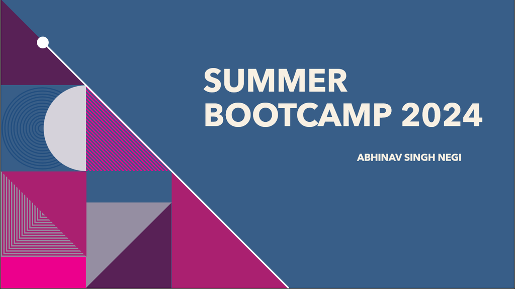

# Index

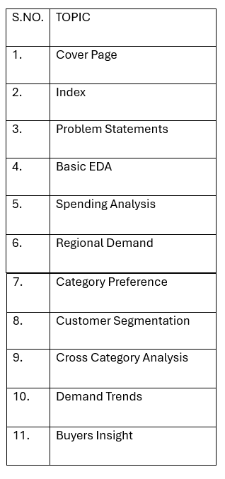

# List of Tables

1. Data Head
2. Data tail
3. Statistical Info
4. Fresh Wrong Entries
5. Null values/ Wrong Entries
6. Statistical Info after Correction

# List of Figures

1. Libraries
2. Dataset
3. Dataset Info
4. data types
5. outliers in numerical column
6. After removing Outliers
7. Dataset information After data cleaning
8. Spending Analysis Figures
9. Regional Demand Figures
10. Category Preference Figures
11. Coustomer Segmentation Figures
12. Cross Category Analysis Figures
13. Demand Trend Figures
14. Buyers Insight Figures

### Problem Statement

A wholesale distributor operating in different regions of Portugal has information on annual spending of several items in their stores across different regions and channels. The data consists of 440 large retailers’ annual spending on 6 different varieties of productsin 3 different regions (Lisbon, Oporto, Other) and across different sales channel (Hotel, Retail).

# Importing the necessary library

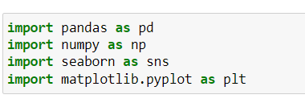

# Loading the dataset

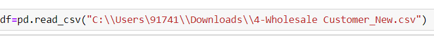

# Basic Data Exploration

1. Checking Head and tail of dataset

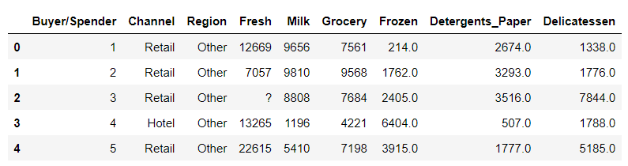

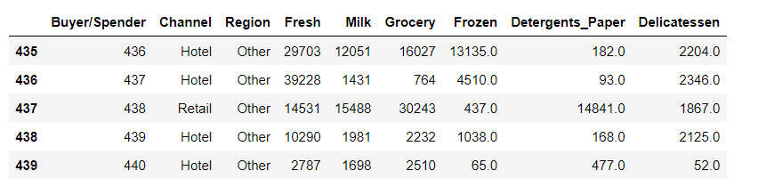

- there is a false value in column Fresh should be numerical but is "?", so we need to correct that later
1. Getting how many columns and information about them
- there are 440 rows and 9 columns

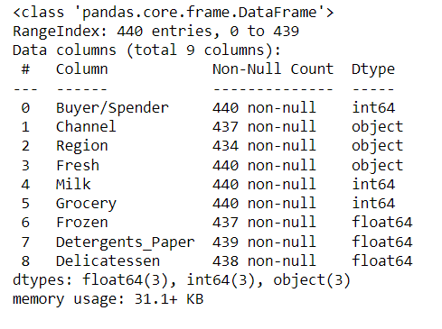

- by information we get to know that there is no null values in columns Buyers/Spenders,Fresh,Milk,Grocery,but fresh has wrong etries that has to be corrected
- fresh catogry should be float/int trype but is object so we have to fix that too
1. Check the datatypes of each feature

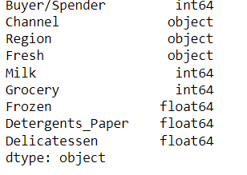

- There are 3 object type ,3 int type and 3 float type features(As of now that can be changed after cleaning and filtering of the datset)
1. Describe the Data
- by describe we get to know the statistical summary of dataset

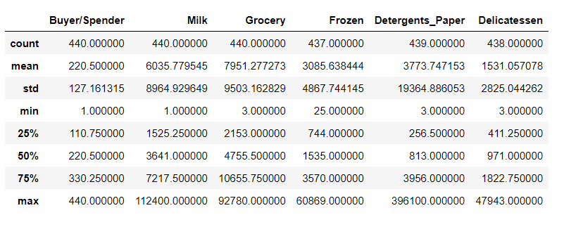

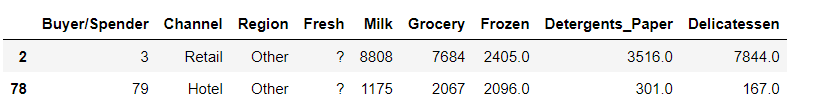

- Spender id 3 and 79 has wrong entries in Fresh column
- After changing the data type and replacing the wrong values by null values in fresh column we can see that now the datatype has been changed and the wrong entries has been set to null.

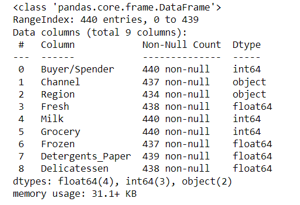

- There are total of 17 null values in the dataset

### Finding and Fixing the null values and wrong entries

##### 1.In catogry Delicatessen

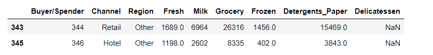

##### 2. In catogry Detergents_Paper

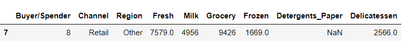

##### 3. In catogry Channel

- Other than hotel and retal in channel there is nan i.e there are values in channel which has not been initialised

##### 4. In catogry Region

- Other than Lisbon and Oporto and Other in Region there is nan i.e there are values in Region which has not been initialised

##### 5. In catogry Frozen

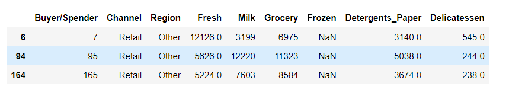

##### 6. In catogry Fresh

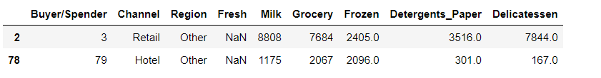

### Handling null values in numeric columns

- Now after finding null Values in each columns to fix those null values and missing values we have to check for Outliers
1. If outliers are present then replace the null values by median of the columns
2. If ouutliers are not present then replace the null values by the median of the column
3. For catagorical column repllace the null/missing values by mode of the column
- checking for outliers

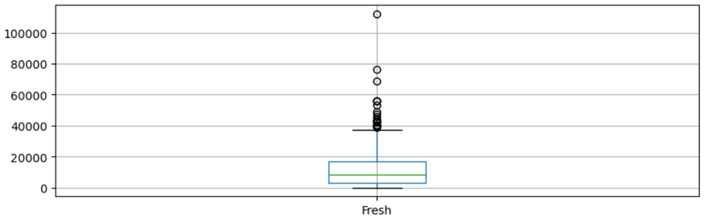

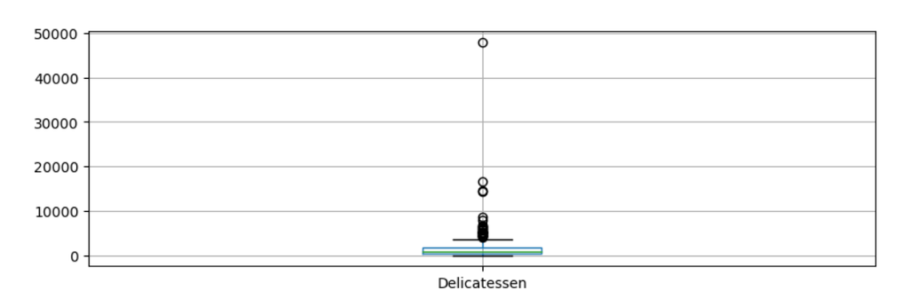

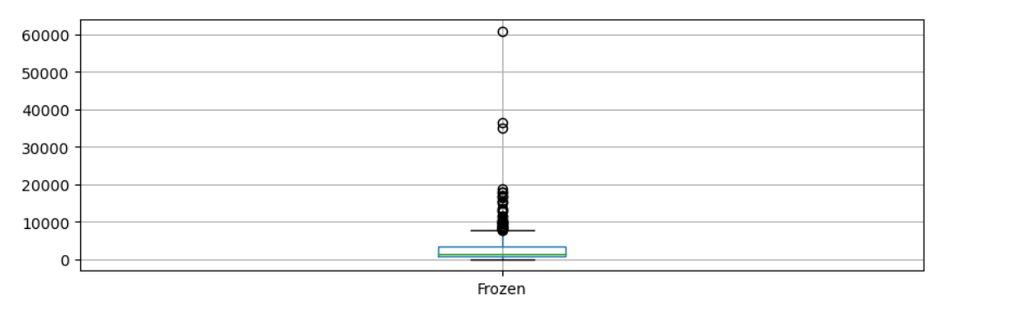

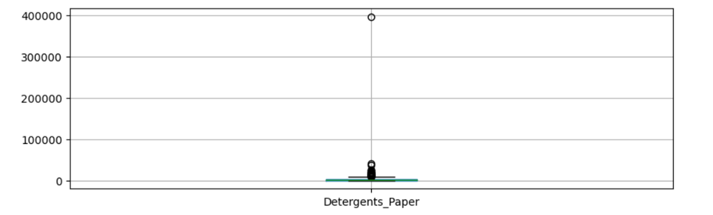

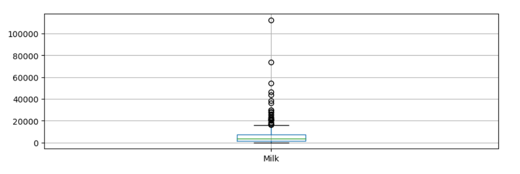

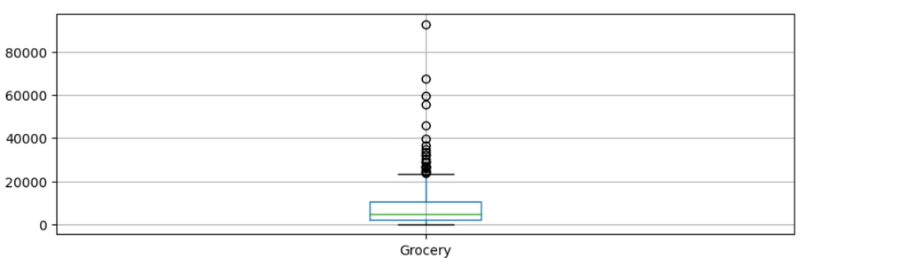

We can see there are outliers in all the numerical columns

- replacing nan values with median, because outliers are present in columns
- after replacing nan values to their median we have done our outlier treatment for numerical columns

### After outlier treatment

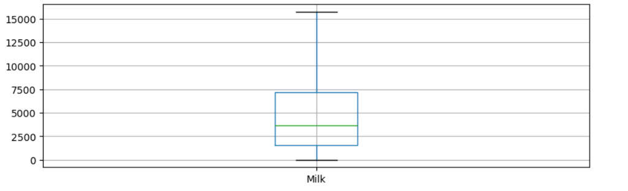

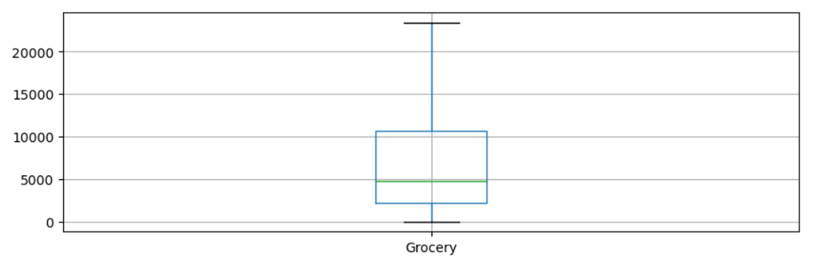

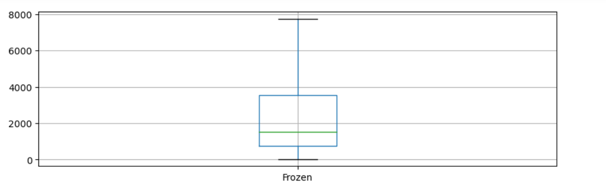

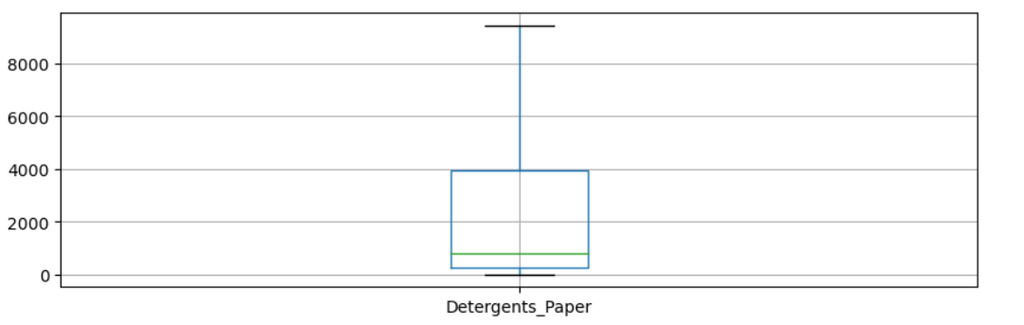

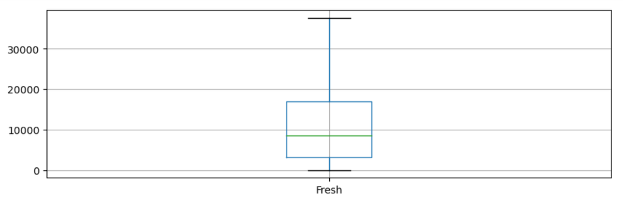

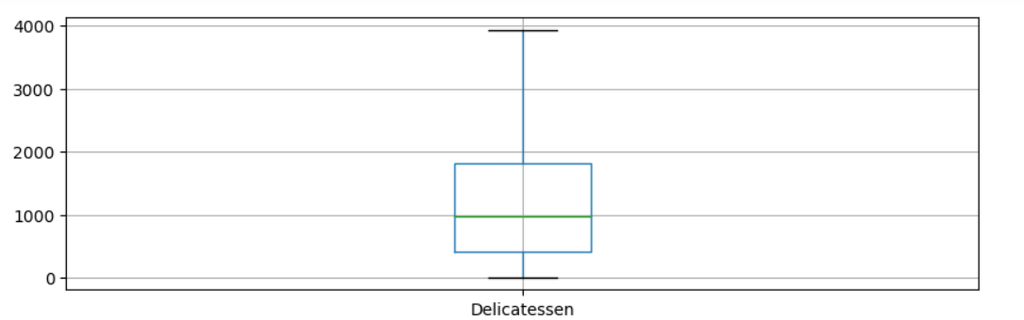

Now observing the correct statistical summary of the corrected columns

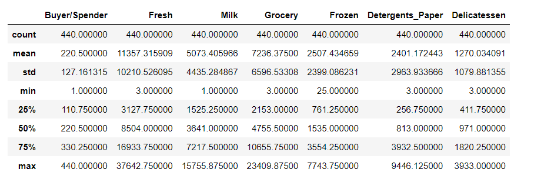

# Handling Missing values in object columns

1. To handle the missing value in the Object columns we have to repklave the missing values by the mode of the column
- now there are no outliers and null values in the dataset

After doing all necessary cleaning and treatment the information about data is

1. There are no null values in the dataset,there are total of 440 buyers/Spenders and 9 columns

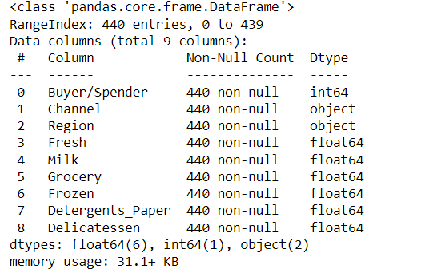

# 1. Spending Analysis

1. Total number of Buyers

there are 440 Buyers/Spenders

1. Average spending on Fresh, Milk, Grocery, Frozen, Detergents_paper, Delicatessen

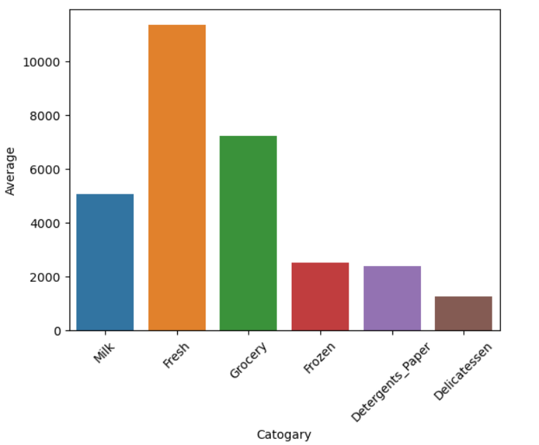

1. Which category has the highest average spending?
- wecan observe that Fresh has largest average spending

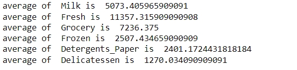

1. How many buyers spend above the average on Fresh Vegetables?
- About 170 Buyers spend above average on fresh vegetables

# 2. Regional demand

1. What is the total spending in each region?

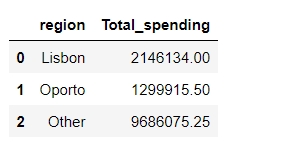

- Lisbon has total spending of 2146134, oporto with total spending of 1299915 and other regions with the spending of 9686075
1. Which region has the highest spending on Milk?
- regions other than Lisbon and Oporto has highest spending on Milk

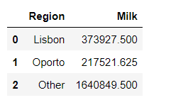

1. How does the average spending on Grocery vary across different regions?
- here is the average spending in every region on grocery
- OPORTO has highest lisbon has least this is how spending vary through rEGION

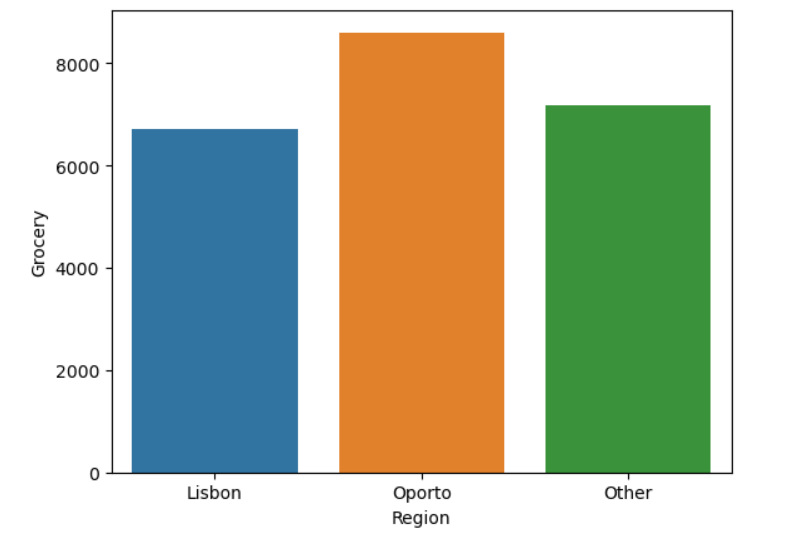

1. no. of buyers/spenders in regions
- Liscon has 75 buyers oporto has 43 spenders and regions other than these two has 322 buyers

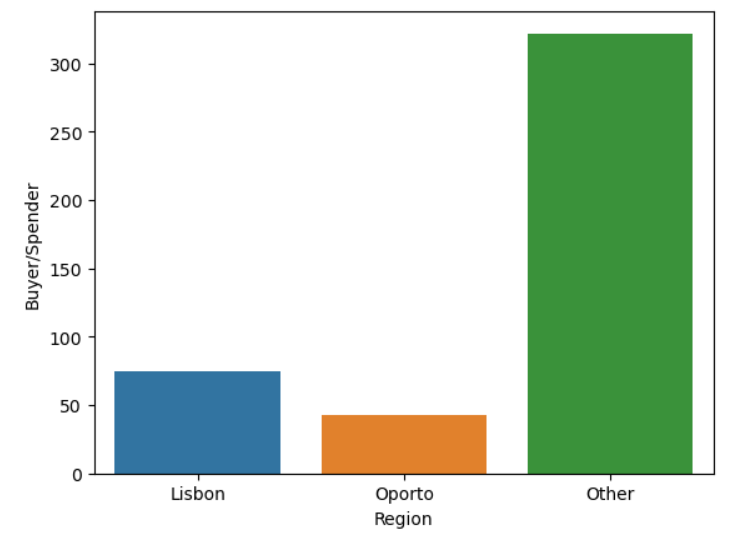

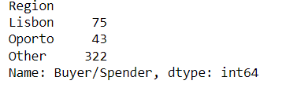

1. Which region has the highest average spending per buyer?
- we can see that Oporto has highest avg. spending per buyer

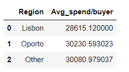

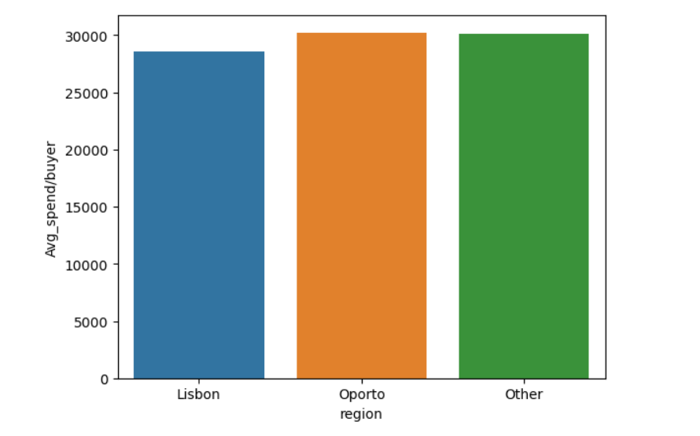

## 3. Category Preference

1. What percentage of buyers spend more on Frozen food compared to Delicatessen?
- 66.13% of buyers/spenders spend more on frozen than delicatessen
1. Which category shows the most variation in spending among buyers?
- we can observe that Fresh has most variation in spending catagory

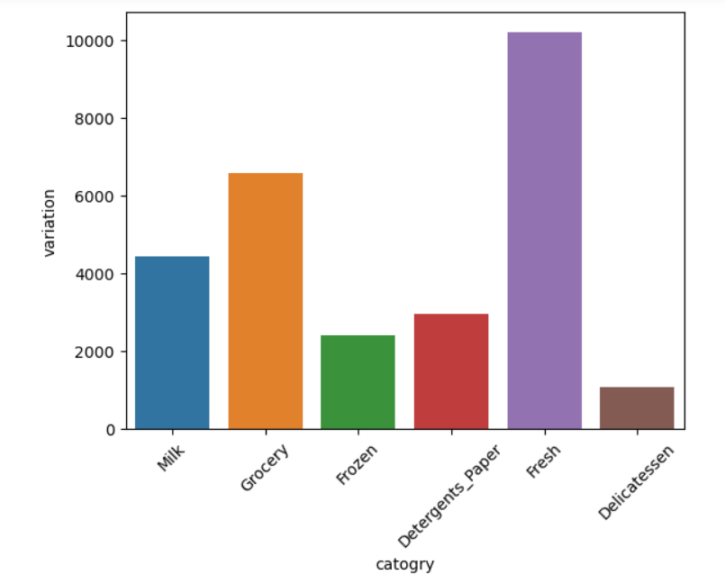

1. Are there any regions where spending on Detergents_paper is significantly higher than others?
- Yes,there is a region where spending on detergents_paper is significatenly higher than other rwgion i.e. Oporto has significatently higher spending than other region

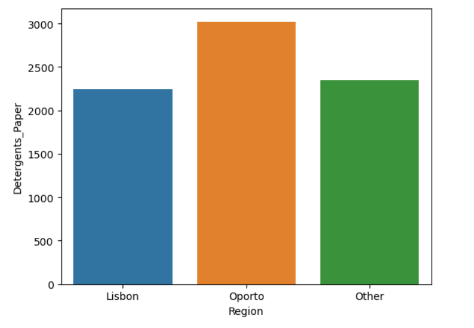

1. What is the correlation between spending on Fresh and Frozen food?
- there is corelation of 0.355 between fresh and frozen

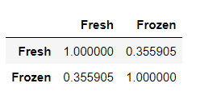

# 4. Customer Segmentation

1. Can buyers be grouped into segments based on their spending patterns? (e.g., using clustering analysis)
- 150 buyers spend in range of 904-20K , 175 buyers spend in range 20K-40K , 85+ buyers spend in range 40K-58K , 20+ spender spend in range 58K-78K,remaining spend in range 78K-97K

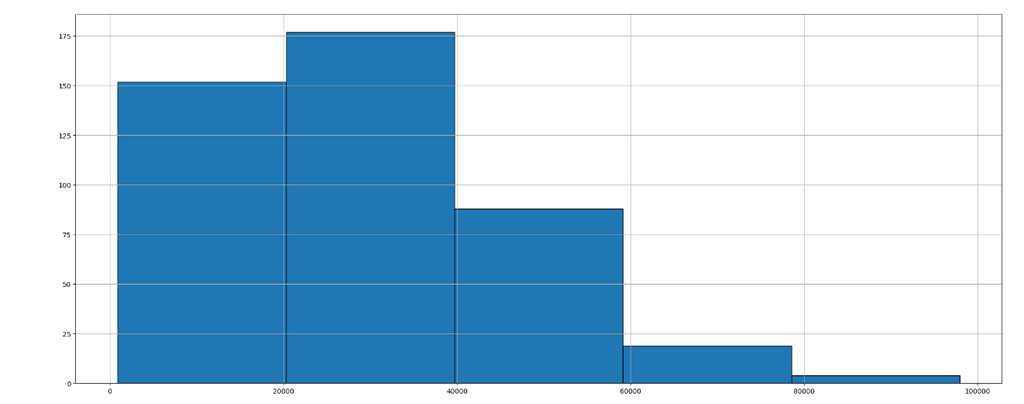

1. What are the characteristics of the top 10% spenders in each category?

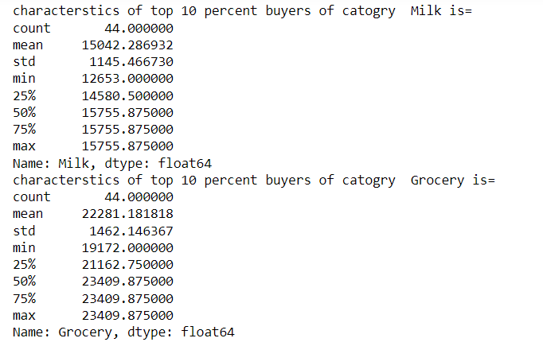

- Milk catogry top 10 percent has max spend of 15755 and min spend of 12653 avg spend by these 10 percent was 15042
- Grocery catogry top 10 percent has max spend of 23409 and min spend of 19172 avg spend by these 10 percent was 22281.18

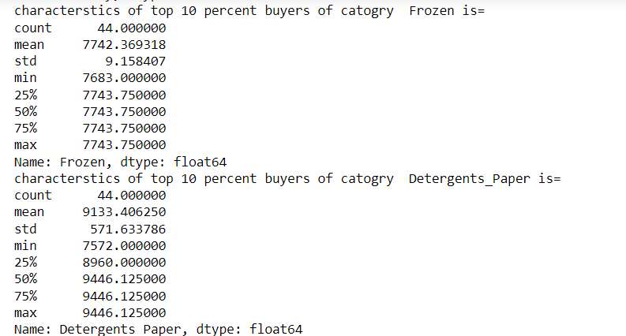

- Frozen catogry top 10 percent has max spend of 7743.75 and min spend of 7683 avg spend by these 10 percent was 7742.36
- Detergents_paper catogry top 10 percent has max spend of 9446.12 and min spend of 7572 avg spend by these 10 percent was 9133.40

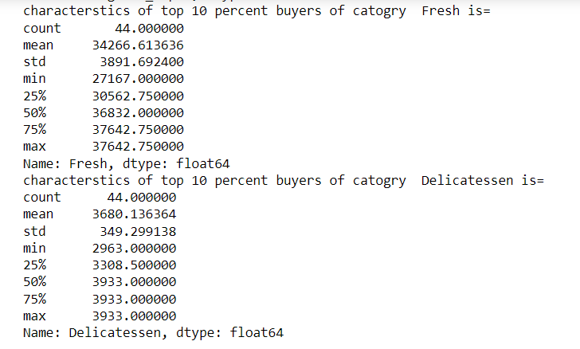

- Fresh catogry top 10 percent has max spend of 37642.75 and min spend of 27167 avg spend by these 10 percent was 34266.61
- Delicatessen catogry top 10 percent has max spend of 3933 and min spend of 2963 avg spend by these 10 percent was 3680.13
1. How do spending patterns differ between high spenders and low spenders?

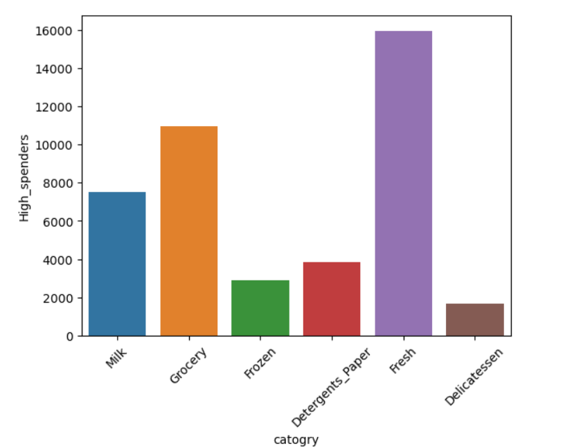

- in high spenders Fresh was most spent on then grocery followed by milk then detergent paper then the second last was frozen and the least spent by high spenders was Delicatessen.

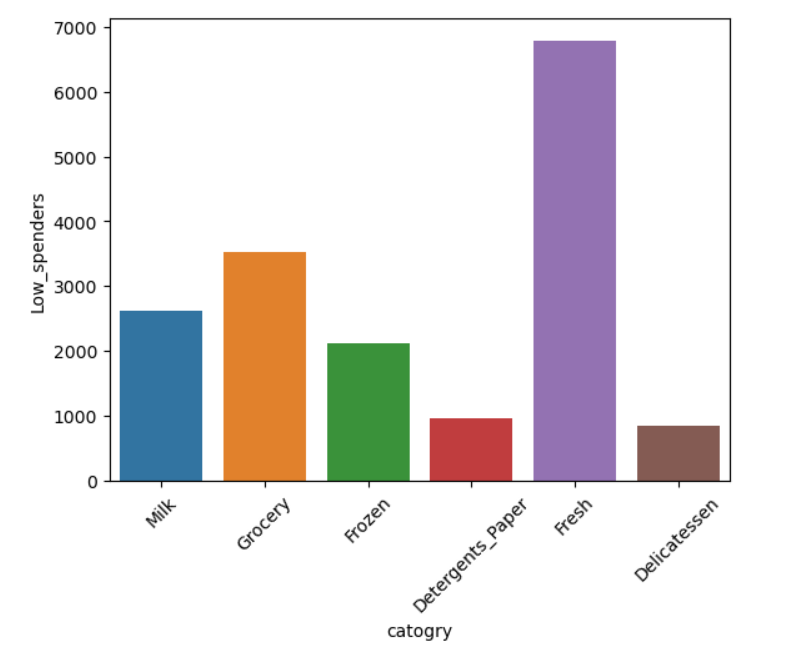

# 5. Cross Category Analysis

1. Is there a correlation between spending on Milk and Grocery?

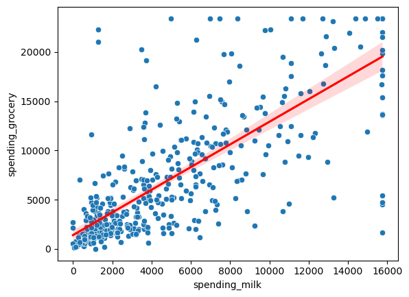

- the scatter plot shows that on the incresing spend on milk also increse the spend on grocery
- between Milk and Grocery there is a corelation of 0.7737
1. Do buyers who spend more on Delicatessen also spend more on Frozen food?

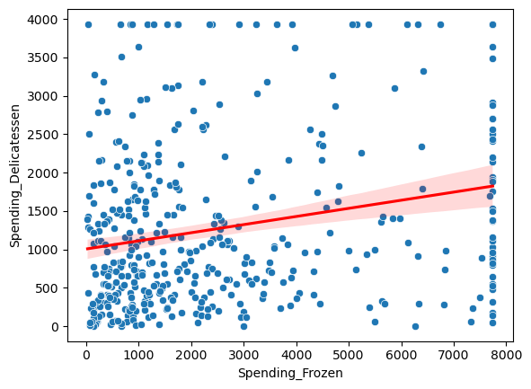

- by this we can observe that buyers that spend more on frozen spend more on delicatessen but the relationship is week
- there is corelation of 0.23 between them
1. What is the combined average spending on Fresh and Milk for each region?

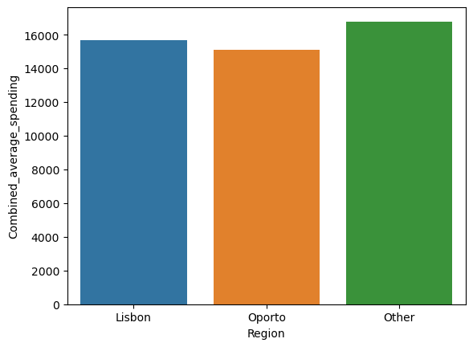

- region other than Lisbon and Oporto has more combined average spending then them.
- Lisbon has more spending than Oporto

# 6. Demand Trends

1. Which region has the fastest growing spending on Fresh Vegetables?

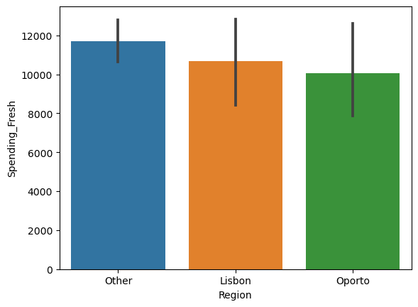

# 7. Buyers Insights

1. What is the repeat purchase rate for buyers who spend above the average in at least three categories?
- Repeat Purchase Rate for buyers who spend above the average in at least three categories: 41.82%
1. How many buyers spend consistently (i.e., similar amounts) across all categories?
- 254 buyers/spenders were those who spend similar amount
- this was achieved by a threshold value ehich was the result of mean of standard deviation
1. Which region has the most diverse spending patterns (i.e., high variance in spending across categories)?
- Region which has the most diverse spending patterns is ( Other ) region with variance of 294748505.8265645